# Project_All_Life_Bank_Customer_Segmentation

### **Import necessary libraries**

```python
from sklearn.cluster import KMeans
import numpy as np
import pandas as pd
import matplotlib.pyplot as plt
import seaborn as sns
sns.set()

from scipy.cluster.hierarchy import dendrogram, linkage,cophenet
from scipy.spatial.distance import pdist
from sklearn.cluster import AgglomerativeClustering

from sklearn.preprocessing import StandardScaler
from scipy.spatial.distance import cdist
from scipy.spatial.distance import pdist
from sklearn.cluster import KMeans
from sklearn.metrics import silhouette_score
from yellowbrick.cluster import KElbowVisualizer, SilhouetteVisualizer

import warnings
warnings.filterwarnings('ignore')

pd.set_option("display.max_columns", None)
pd.set_option("display.max_rows", 200)
```

### Read the dataset

```python
data= pd.read_excel('Credit Card Customer Data.xlsx')
```

### Getting some information and data types about the data

```python
data.info()
```

```
<class 'pandas.core.frame.DataFrame'>
RangeIndex: 660 entries, 0 to 659
Data columns (total 7 columns):
 #   Column               Non-Null Count  Dtype
---  ------               --------------  -----
 0   Sl_No                660 non-null    int64
 1   Customer Key         660 non-null    int64
 2   Avg_Credit_Limit     660 non-null    int64
 3   Total_Credit_Cards   660 non-null    int64
 4   Total_visits_bank    660 non-null    int64
 5   Total_visits_online  660 non-null    int64
 6   Total_calls_made     660 non-null    int64
dtypes: int64(7)
memory usage: 36.2 KB
```

**Observations**

- Dataset is presented in numerical form only.
- Data does not seem to have missing values. Further check will be needed to double check it.

```python
#Visualization first 5 rows
data.head()
```

|  | Sl_No | Customer Key | Avg_Credit_Limit | Total_Credit_Cards | Total_visits_bank | Total_visits_online | Total_calls_made |
| --- | --- | --- | --- | --- | --- | --- | --- |
| 0 | 1 | 87073 | 100000 | 2 | 1 | 1 | 0 |
| 1 | 2 | 38414 | 50000 | 3 | 0 | 10 | 9 |
| 2 | 3 | 17341 | 50000 | 7 | 1 | 3 | 4 |
| 3 | 4 | 40496 | 30000 | 5 | 1 | 1 | 4 |
| 4 | 5 | 47437 | 100000 | 6 | 0 | 12 | 3 |

```python
#Visualization last 5 rows
data.tail()
```

|  | Sl_No | Customer Key | Avg_Credit_Limit | Total_Credit_Cards | Total_visits_bank | Total_visits_online | Total_calls_made |
| --- | --- | --- | --- | --- | --- | --- | --- |
| 655 | 656 | 51108 | 99000 | 10 | 1 | 10 | 0 |
| 656 | 657 | 60732 | 84000 | 10 | 1 | 13 | 2 |
| 657 | 658 | 53834 | 145000 | 8 | 1 | 9 | 1 |
| 658 | 659 | 80655 | 172000 | 10 | 1 | 15 | 0 |
| 659 | 660 | 80150 | 167000 | 9 | 0 | 12 | 2 |

```python
#Reading data colomuns
data.columns
```

```
Index(['Sl_No', 'Customer Key', 'Avg_Credit_Limit', 'Total_Credit_Cards',
       'Total_visits_bank', 'Total_visits_online', 'Total_calls_made'],
      dtype='object')
```

```python
#Replacing space by underline on the column name: Customer Key
data.columns=['Sl_No', 'Customer_Key', 'Avg_Credit_Limit', 'Total_Credit_Cards','Total_visits_bank', 'Total_visits_online', 'Total_calls_made']
```

```python
#Get some descriptive statistics from the dataset
data.describe(include='all').T
```

[output not shown]

**Observations**

- Average Credit Limit variable is right skewed distributed since its mean is bigger than its median.
- Other variables do not present a big range starting from 0 to max 15.

### Checking for duplicated entries

```python
#Checking Duplicated per column
columns = data.columns
for i in columns:
    x = data[i].duplicated().sum()
    print('Quantity of duplicated entries per column name: {} are'.format(i), x)
    print('-'*90)
```

```
Quantity of duplicated entries per column name: Sl_No are 0
------------------------------------------------------------------------------------------
Quantity of duplicated entries per column name: Customer_Key are 5
------------------------------------------------------------------------------------------
Quantity of duplicated entries per column name: Avg_Credit_Limit are 550
------------------------------------------------------------------------------------------
Quantity of duplicated entries per column name: Total_Credit_Cards are 650
------------------------------------------------------------------------------------------
Quantity of duplicated entries per column name: Total_visits_bank are 654
------------------------------------------------------------------------------------------
Quantity of duplicated entries per column name: Total_visits_online are 644
------------------------------------------------------------------------------------------
Quantity of duplicated entries per column name: Total_calls_made are 649
------------------------------------------------------------------------------------------
```

**Observations**

- Concerns are more on lower values than big ones. For instance Customer key, which is the ID of the customer have 5 duplicated entries. Further check will be done.
- All the variables starting with word 'Total' have a high number of duplicated since their range of unique values is very low.

```python
#Getting all values that are duplicated in variable 'Customer_Key'
y = data[data['Customer_Key'].duplicated()].Customer_Key.values
print(y)
```

```
[47437 96929 37252 50706 97935]
```

```python
#Get all indexes that are duplicated
List = []
for i in y:
    x =data[data['Customer_Key']==(i)].index.tolist()
    List.append(x)
```

```python
print(List)
```

```
[[4, 332], [391, 398], [48, 432], [411, 541], [104, 632]]
```

```python
#As last line resulted in a list of lists
#This code is made to consolidate in one list
#Check if this works list(itertools.chain.from_iterable(list2d))
import itertools
List_merged = list(itertools.chain.from_iterable(List))
```

```python
List_merged
```

```
[4, 332, 391, 398, 48, 432, 411, 541, 104, 632]
```

```python
#Showing Duplicated items
data.iloc[List_merged]
```

|  | Sl_No | Customer_Key | Avg_Credit_Limit | Total_Credit_Cards | Total_visits_bank | Total_visits_online | Total_calls_made |
| --- | --- | --- | --- | --- | --- | --- | --- |
| 4 | 5 | 47437 | 100000 | 6 | 0 | 12 | 3 |
| 332 | 333 | 47437 | 17000 | 7 | 3 | 1 | 0 |
| 391 | 392 | 96929 | 13000 | 4 | 5 | 0 | 0 |
| 398 | 399 | 96929 | 67000 | 6 | 2 | 2 | 2 |
| 48 | 49 | 37252 | 6000 | 4 | 0 | 2 | 8 |
| 432 | 433 | 37252 | 59000 | 6 | 2 | 1 | 2 |
| 411 | 412 | 50706 | 44000 | 4 | 5 | 0 | 2 |
| 541 | 542 | 50706 | 60000 | 7 | 5 | 2 | 2 |
| 104 | 105 | 97935 | 17000 | 2 | 1 | 2 | 10 |
| 632 | 633 | 97935 | 187000 | 7 | 1 | 7 | 0 |

**Observations**

- All duplicated observations have their variables completly distinct from one another and any attempt to remove those rows would cause a lack of data. As vaiable "SI_No" also represents a sort of identification and it is not duplicated "Customer_Key" will be interpreted as errors and no further actions will be done.

### Checking for missing values

```python
#Checking for missing values per column
columns = data.columns
for i in columns:
    x = data[i].isnull().sum().sum()
    print('Quantity of missing entries per column name: {} are'.format(i), x)
    print('-'*90)
```

```
Quantity of missing entries per column name: Sl_No are 0
------------------------------------------------------------------------------------------
Quantity of missing entries per column name: Customer_Key are 0
------------------------------------------------------------------------------------------
Quantity of missing entries per column name: Avg_Credit_Limit are 0
------------------------------------------------------------------------------------------
Quantity of missing entries per column name: Total_Credit_Cards are 0
------------------------------------------------------------------------------------------
Quantity of missing entries per column name: Total_visits_bank are 0
------------------------------------------------------------------------------------------
Quantity of missing entries per column name: Total_visits_online are 0
------------------------------------------------------------------------------------------
Quantity of missing entries per column name: Total_calls_made are 0
------------------------------------------------------------------------------------------
```

```python
# Lets see unique values
colmns = data.columns
for col in colmns:
    print('Unique Values of {} are \n'.format(col),data[col].unique())
    print('*'*90)
```

[output not shown]

[output cut: 99 more lines]

**Observations**

- No further corrections should be done.
- dataset is ready for EDA, Pre_processing and modeling.

```python
#Removing columns that do not add value to analysis
data=data.drop(['Customer_Key','Sl_No'],axis=1)
```

```python
#Double Checkigng removed variables
data.head()
```

|  | Avg_Credit_Limit | Total_Credit_Cards | Total_visits_bank | Total_visits_online | Total_calls_made |
| --- | --- | --- | --- | --- | --- |
| 0 | 100000 | 2 | 1 | 1 | 0 |
| 1 | 50000 | 3 | 0 | 10 | 9 |
| 2 | 50000 | 7 | 1 | 3 | 4 |
| 3 | 30000 | 5 | 1 | 1 | 4 |
| 4 | 100000 | 6 | 0 | 12 | 3 |

### EDA

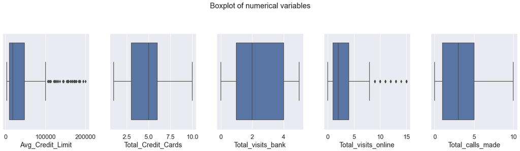

```python
all_col = data.iloc[:,0:].columns.tolist()
sns.set(font_scale=1.5)
fig, axes = plt.subplots(1, 5,  figsize=(20, 6))
fig.suptitle('Boxplot of numerical variables', fontsize=20)
counter = 0
for ii in range(5):
    sns.boxplot(ax=axes[ii],x=data[all_col[counter]])
    counter = counter+1

fig.tight_layout(pad=2.0)
```

**Observations**

- Average credit limit variable present a big amount of outliers. Since the scope of this project is to use K-means and this algorithm is sensitive to outliers this vaiable will be treated before model building.
- Average credit limit ranging from 10 - 50K most of the cases. Outliers are afecting the mean.
- Total visits online also present some outliers but as they represent a very small amount it will not compromise model building step.

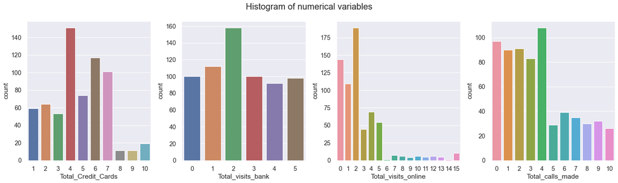

```python
all_col = data.iloc[:,1:].columns.tolist()
sns.set(font_scale=1.3)
fig, axes = plt.subplots(1, 4,  figsize=(20, 6))
fig.suptitle('Histogram of numerical variables', fontsize=20)
counter = 0
for ii in range(4):
    sns.countplot(ax=axes[ii],x=data[all_col[counter]])
    counter = counter+1

fig.tight_layout(pad=1.0)
```

**Observations**

- Most of the customers have 4 credit cards, followed by 6, 7 and 5 credit cards.
- Credit card number higher than 8 is not so frequent.
- Total visits online in most cases are between 0 - 5.
- Most calls made to Bank's support team were from 0-4, with 4 calls being the most frequent case followed by 0 and 2.

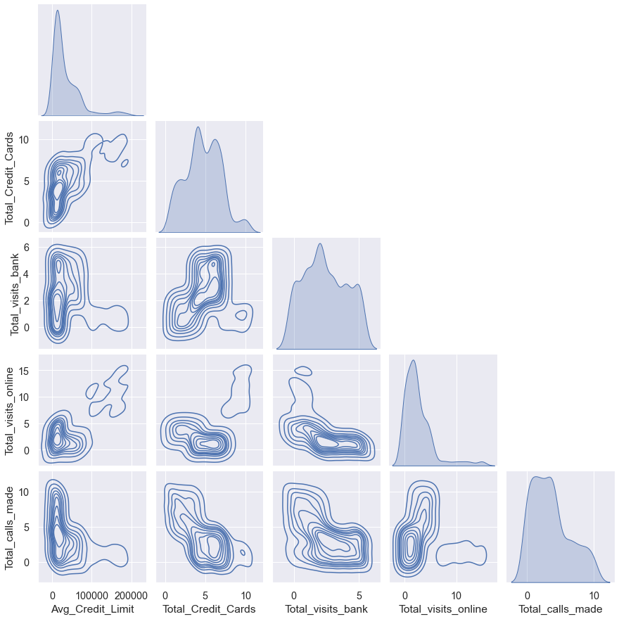

```python
sns.pairplot(data=data, corner=True, kind='kde')
```

**Observations**

- Kde was used in an attempt to visualize some clusters within variables:
  - From what can be see in almost all varibles a number of clusters not smaller than 2 and maybe up to 3 clusters.

## Bivariate Analysis

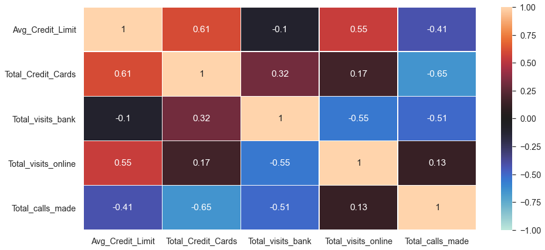

```python
plt.figure(figsize=(15,7))

all_col0 = data.iloc[:,0:].columns.tolist()

sns.heatmap(data[all_col0].corr(),
            annot=True,
            linewidths=0.5,vmin=-1,vmax=1,
            center=0,
            cbar=True,)

plt.show()
```

**Observations**

- As intuitively we may think of it the data shows a negative correlation between visits online and visit to the bank, where it can tell as more as people acess online banking less they go to their physical branch.
- It can also be observed a positive correlation between visits to the bank and total number of credit card. As the number of visits increase the number of cards also increases. This indicates that the work and offers made inside the branch bring a positive result in the number of credit cards a customer have.
- Visits online also have a positive correlation with number of credit cards but it is almost half of the number in comparison to visit in the physical branch.
- Total calls made have a negative correlation with visits to the bank, indicating as more as customer call to the bank less they go to the their physical branch.
- Total call made also have a negative correlation with Total credit card number, as the number of call increses, the number of credit cards decrease. This may indicate a poor quality service that result in a credit card cancelation. -Average credit limit have a high correlation number of visits online.

### Outliers Treatment

Variable Average Credit Limit was selected to be treated due its big amount of outliers and this can significantly impact distance based model, in other words any model which use distance as the base of their calculation. One example would be outliers in K-means since it can shift clusters centroid towards the farthest points of the clusters pulling it off center from its cluster. As observed in the box plots in EDA part outliers are in the upper end.

```python
#Calculating Quantiles for further processing
Q1 = data.Avg_Credit_Limit.quantile(0.25)
Q3 = data.Avg_Credit_Limit.quantile(0.75)
IQR = Q3 - Q1
Q3
```

```
48000.0
```

```python
#Storing indexes with quantile higher than Q3
x = data.loc[data['Avg_Credit_Limit'] > (Q3 + 1.5 * IQR)].index.tolist()
```

```python
#Changing indexes with quantile higher than Q3 to Q3 value.
for i in x:
    data.loc[i][0] = Q3
```

```python
#Double checking one index that was initially higher than Q3
data.loc[622][0]
```

```
48000
```

```python
#Checking if is there any datapoint higher than Q3
data.loc[data['Avg_Credit_Limit'] > (Q3 + 1.5 * IQR)]
```

|  | Avg_Credit_Limit | Total_Credit_Cards | Total_visits_bank | Total_visits_online | Total_calls_made |
| --- | --- | --- | --- | --- | --- |

### Model Building - First Part K-Means

```python
# Scaling the data set before clustering
scaler=StandardScaler()
subset=data[all_col1].copy()
subset_scaled=scaler.fit_transform(subset)
```

```python
#Creating a dataframe from the scaled data above for K-means and Hierarchical Clustering
subset_scaled_df_k=pd.DataFrame(subset_scaled,columns=subset.columns)
subset_scaled_df_h=pd.DataFrame(subset_scaled,columns=subset.columns)
subset_scaled_df_k
```

|  | Avg_Credit_Limit | Total_Credit_Cards | Total_visits_bank | Total_visits_online | Total_calls_made |
| --- | --- | --- | --- | --- | --- |
| 0 | 3.212943 | -1.249225 | -0.860451 | -0.547490 | -1.251537 |
| 1 | 0.972444 | -0.787585 | -1.473731 | 2.520519 | 1.891859 |
| 2 | 0.972444 | 1.058973 | -0.860451 | 0.134290 | 0.145528 |
| 3 | 0.076245 | 0.135694 | -0.860451 | -0.547490 | 0.145528 |
| 4 | 3.212943 | 0.597334 | -1.473731 | 3.202298 | -0.203739 |
| ... | ... | ... | ... | ... | ... |
| 655 | 3.168133 | 2.443892 | -0.860451 | 2.520519 | -1.251537 |
| 656 | 2.495983 | 2.443892 | -0.860451 | 3.543188 | -0.553005 |
| 657 | 0.882824 | 1.520613 | -0.860451 | 2.179629 | -0.902271 |
| 658 | 0.882824 | 2.443892 | -0.860451 | 4.224968 | -1.251537 |
| 659 | 0.882824 | 1.982253 | -1.473731 | 3.202298 | -0.553005 |

660 rows × 5 columns

```
Number of Clusters: 1 	Average Distortion: 2.1679165571124153
Number of Clusters: 2 	Average Distortion: 1.5610770048697773
Number of Clusters: 3 	Average Distortion: 1.2798540852070142
Number of Clusters: 4 	Average Distortion: 1.1161553817185799
Number of Clusters: 5 	Average Distortion: 1.0523543270659084
Number of Clusters: 6 	Average Distortion: 0.9964101182110883
Number of Clusters: 7 	Average Distortion: 0.9567230175736764
Number of Clusters: 8 	Average Distortion: 0.9352674638528067
```

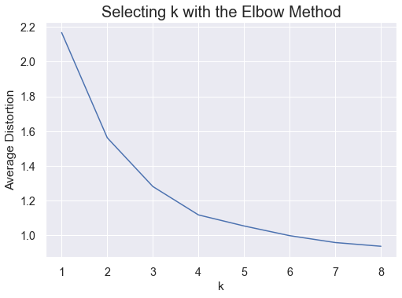

```python
clusters=range(1,9)
meanDistortions=[]

for k in clusters:
    model=KMeans(n_clusters=k)
    model.fit(subset_scaled_df_k)
    prediction=model.predict(subset_scaled_df_k)
    distortion=sum(np.min(cdist(subset_scaled_df_k, model.cluster_centers_, 'euclidean'), axis=1)) / subset_scaled_df_k.shape[0]

    meanDistortions.append(distortion)

    print('Number of Clusters:', k, '\tAverage Distortion:', distortion)

plt.plot(clusters, meanDistortions, 'bx-')
plt.xlabel('k')
plt.ylabel('Average Distortion')
plt.title('Selecting k with the Elbow Method', fontsize=20)
```

**Observations**

- The appropriate value of k from elbow curve seems to between 4 and 6.

### Lets us check silhoutte score

```python
sil_score = []
cluster_list = list(range(2,10))
for n_clusters in cluster_list:
    clusterer = KMeans(n_clusters=n_clusters)
    preds = clusterer.fit_predict((subset_scaled_df_k))
    #centers = clusterer.cluster_centers_
    score = silhouette_score(subset_scaled_df_k, preds)
    sil_score.append(score)
    print("For n_clusters = {}, silhouette score is {})".format(n_clusters, score))
```

```
For n_clusters = 2, silhouette score is 0.40580338912584946)
For n_clusters = 3, silhouette score is 0.48264886174941785)
For n_clusters = 4, silhouette score is 0.4046826469231681)
For n_clusters = 5, silhouette score is 0.3536541795560874)
For n_clusters = 6, silhouette score is 0.2745275398790752)
For n_clusters = 7, silhouette score is 0.2616067591286536)
For n_clusters = 8, silhouette score is 0.25342929561978905)
For n_clusters = 9, silhouette score is 0.23628904298854597)
```

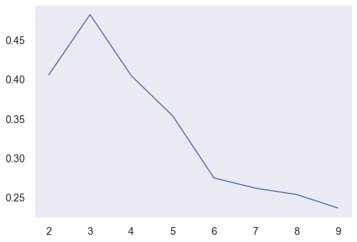

```python
plt.plot(cluster_list,sil_score)
plt.grid()
```

**Observations**

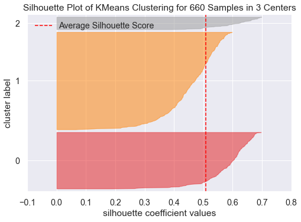

```python
#Finding optimal no. of clusters with silhouette coefficients
visualizer = SilhouetteVisualizer(KMeans(3, random_state = 1))
visualizer.fit(subset_scaled_df_k)
visualizer.show()
```

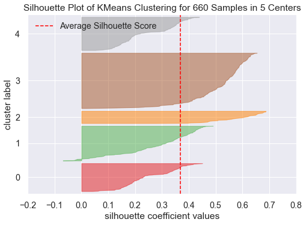

```python
#Finding optimal no. of clusters with silhouette coefficients
visualizer = SilhouetteVisualizer(KMeans(5, random_state = 1))
visualizer.fit(subset_scaled_df_k)
visualizer.show()
```

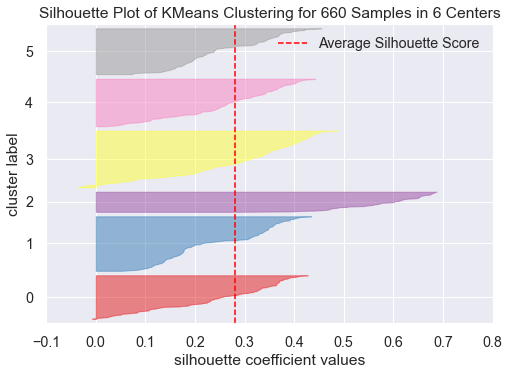

```python
#Finding optimal no. of clusters with silhouette coefficients
visualizer = SilhouetteVisualizer(KMeans(6, random_state = 1))
visualizer.fit(subset_scaled_df_k)
visualizer.show()
```

**Observations**

```python
#Running K-means with optimal K
kmeans = KMeans(n_clusters=6, random_state=0)
kmeans.fit(subset_scaled_df_k)
```

```
KMeans(n_clusters=6, random_state=0)
```

```python
#Creating a variable with the assigned clusters
subset_scaled_df_k['K_means_segments'] = kmeans.labels_
```

### Cluster Profiling

```python
#Creating a variable and storing the mean
cluster_profile = subset_scaled_df_k.groupby('K_means_segments').mean()
```

```python
#Changing the dataframe to show clusters with their mean and the count of each datapoint from each cluster
cluster_profile['count_in_each_segment'] = subset_scaled_df_k.groupby('K_means_segments')['Avg_Credit_Limit'].count().values
```

```python
cluster_profile
```

| K_means_segments | Avg_Credit_Limit | Total_Credit_Cards | Total_visits_bank | Total_visits_online | Total_calls_made | count_in_each_segment |
| --- | --- | --- | --- | --- | --- | --- |
| 0 | -0.399945 | 0.345843 | 1.322644 | -0.529682 | -0.560824 | 134 |
| 1 | -0.409463 | 0.403610 | 0.064945 | -0.556621 | -0.553005 | 112 |
| 2 | -0.702011 | -1.048891 | -1.005092 | 0.378701 | 1.760060 | 106 |
| 3 | 1.387897 | 0.376406 | 0.519430 | -0.574274 | -0.545521 | 140 |
| 4 | 1.339886 | 1.862226 | -1.105763 | 2.827319 | -0.874330 | 50 |
| 5 | -0.740967 | -1.069264 | -0.808478 | 0.272957 | 0.598390 | 118 |

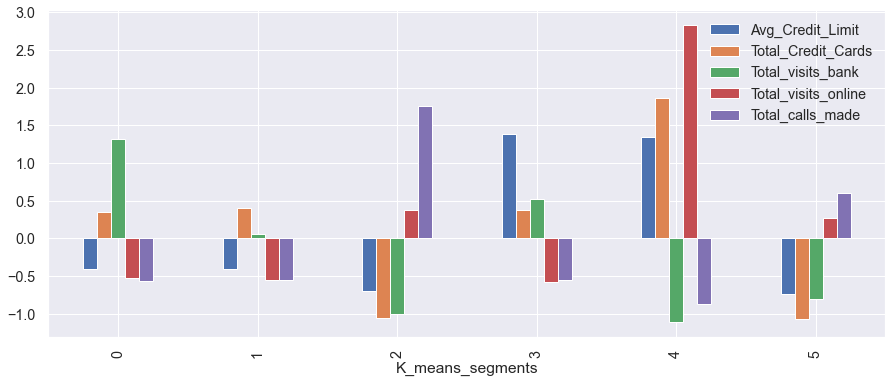

```python
#Plotting bar plot of the clusters by variables
subset_scaled_df_k.groupby('K_means_segments').mean().plot.bar(figsize=(15,6))
```

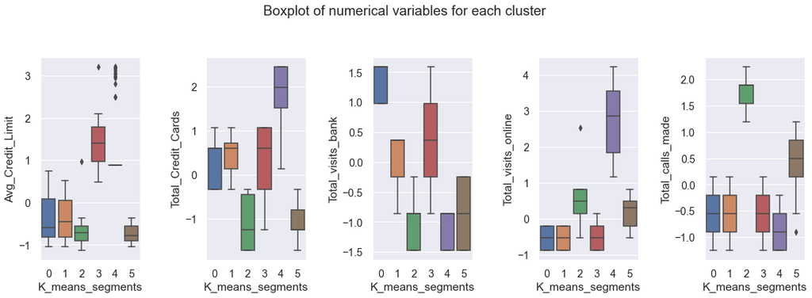

```python
#Plotting box plots of the clusters by variables
all_col3 = data.iloc[:,0:].columns.tolist()
fig, axes = plt.subplots(1, 5,  figsize=(16, 6))
fig.suptitle('Boxplot of numerical variables for each cluster')
counter = 0
for ii in range(5):
    sns.boxplot(ax=axes[ii],y=subset_scaled_df_k[all_col3[counter]],x=subset_scaled_df_k['K_means_segments'])
    counter = counter+1

fig.tight_layout(pad=2.0)
```

**Insights**

- Clusters 0 :
  - Average credit limit is below the average of 28298.
  - Total credit cards is slightly above the average of 4 cards
  - Total visits Bank is the highest among all clusters
  - Total visits online is well below the average of 2.
  - Total calls made is well below the average of 3.
- Cluster 1 :
  - Average credit limit is below the average of 28298.
  - Total credit cards is slightly above the average of 4 cards.
  - Total visits Bank is right at the average of 2 visits.
  - Total visits online is well below the average of 2.
  - Total calls made is is well below the average of 3.
- Cluster 2 :
  - Average credit limit is the 2nd lowest among all clusters.
  - Total credit cards is the 2nd lowest among clusters.
  - Total visits Bank is the 2nd lowest among clusters.
  - Total visits online is slightly above the average of 2.
  - Total calls made is the highest among all clusters.
- Cluster 3:
  - Average credit limit is the highest among all clusters.
  - Total credit cards is close to the average of 4 cards.
  - Total visits Bank is close to the average of 2 visits.
  - Total visits online is below the average of 2.
  - Total calls is below the average of 3.
- Cluster 4:
  - Average credit limit is 2nd highest among all clusters.
  - Total credit cards is the highest among all clusters.
  - Total visits Bank is the lowest among all clusters.
  - Total visits online is the highest among all clusters.
  - Total calls made is the lowest among all clusters.
- Cluster 5:
  - Average credit limit is the lowest among all clusters.
  - Total credit cards is the lowest among all clusters.
  - Total visits Bank is below the average of 2 visits.
  - Total visits online is slightly above the average of 2.
  - Total calls made is slightly above the average of 3.

### Business Recommendation

- **Cluster 4**: is a cluster of customers which predominantly prefer online services, they do have a great number of cards and high credit limit where they represent a very valuable clusters with high profetebility and lower costs. **Bank can upsell products to such group since they tend to accept more cards or credit limit increase offering.**
- **Cluster 0**: are customers which prefer presencial visit and since there is a positive correlation between visits to the bank and number of cards this group can be target to upsell credit cards.
- **Cluster 2**: are the group of customers which the make a strong use of phone calls to solve their queries. **This groups of customers are the ones Bank should invest to better understand their needs related to support service so that Bank can improve their service delivery model based on the feeback of this cluster.**
- **Cluster 3**: are the group of customers with the highest average credit limit. Most of customers with high credit limit do not fear credit and pursue a great responsability to manage their finances. **Bank can offer different products like investiment funds, savings account with returns over investiments or retirement plans in order to increase its penetration in the market**
- **Cluster 5**: are customers with very low number of cards and credit limit. These customers might be included on the bottom of the list in regard to investiment priorities.
- **Cluster 1**: are customers with very low credit limit but above the average in number of cards. These customers should be verified in regard to their credit score so that credit limit increases might be offered.

**In order to target new customers a combination of this study with personal data from customers would be valuable and help to define customers profiles to better target advertisements and further investments.**

### Model Building - Second Part Hierarchical Clustering

```python
#Using a copy of the dataset created only for Hierarchical Clustering
subset_scaled_df_h
```

|  | Avg_Credit_Limit | Total_Credit_Cards | Total_visits_bank | Total_visits_online | Total_calls_made |
| --- | --- | --- | --- | --- | --- |
| 0 | 3.212943 | -1.249225 | -0.860451 | -0.547490 | -1.251537 |
| 1 | 0.972444 | -0.787585 | -1.473731 | 2.520519 | 1.891859 |
| 2 | 0.972444 | 1.058973 | -0.860451 | 0.134290 | 0.145528 |
| 3 | 0.076245 | 0.135694 | -0.860451 | -0.547490 | 0.145528 |
| 4 | 3.212943 | 0.597334 | -1.473731 | 3.202298 | -0.203739 |
| ... | ... | ... | ... | ... | ... |
| 655 | 3.168133 | 2.443892 | -0.860451 | 2.520519 | -1.251537 |
| 656 | 2.495983 | 2.443892 | -0.860451 | 3.543188 | -0.553005 |
| 657 | 0.882824 | 1.520613 | -0.860451 | 2.179629 | -0.902271 |
| 658 | 0.882824 | 2.443892 | -0.860451 | 4.224968 | -1.251537 |
| 659 | 0.882824 | 1.982253 | -1.473731 | 3.202298 | -0.553005 |

660 rows × 5 columns

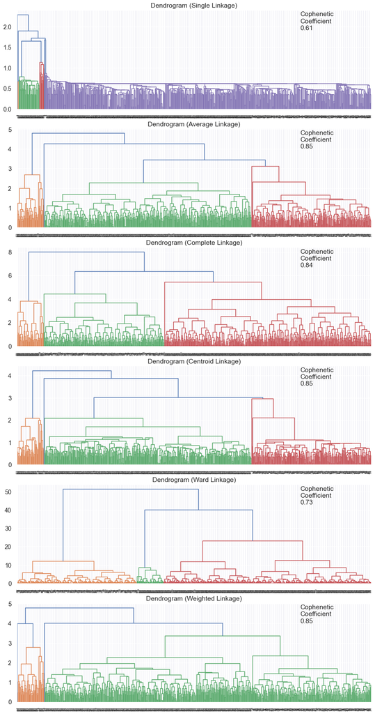

```python
# List of all linkage methods to check
methods = ['single',
           'average',
           'complete',
           'centroid',
           'ward',
          'weighted']

# Calculate the pairwise distance form the dataset to be used in the cophenetic correlation calculation
#pw_distance = pdist(credit_scaled)

# Create lists to save results of coph calculation
compare_cols = ['Linkage', 'Cophenetic Coefficient']
# compare = []

# Create a subplot image
fig, axs = plt.subplots(len(methods), 1, figsize=(15, 30))

# Enumerate through the list of all methods above
# Get linkage, plot dendrogram, calculate cophenetic coefficient
for i, method in enumerate(methods):

    Z = linkage(subset_scaled_df_h, metric='euclidean', method=method)

    dendrogram(Z, ax=axs[i]);
    axs[i].set_title(f'Dendrogram ({method.capitalize()} Linkage)')
    coph_corr, coph_dist = cophenet(Z, pdist(subset_scaled_df_h))
    axs[i].annotate(f'Cophenetic\nCoefficient\n{coph_corr:0.2f}',
                    (0.80, 0.80),
                    xycoords='axes fraction')
#     compare.append([method, coph_corr])
```

**Observations**

### Creating 6 clusters

```python
#Trying with K value as 6
HCmodel = AgglomerativeClustering(n_clusters=6,affinity='euclidean', linkage='ward')
HCmodel.fit(subset_scaled_df_h)
subset_scaled_df_h['HC_Clusters'] = HCmodel.labels_
```

```python
data['HC_Clusters'] = HCmodel.labels_
```

### Cluster Profiling

```python
cluster_profile = data.groupby('HC_Clusters').mean()
```

```python
cluster_profile['count_in_each_segments'] = data.groupby('HC_Clusters')['Total_visits_online'].count().values
```

```python
# lets display cluster profile
cluster_profile.style.highlight_max(color = 'lightgreen', axis = 0)
```

| HC_Clusters | Avg_Credit_Limit | Total_Credit_Cards | Total_visits_bank | Total_visits_online | Total_calls_made | count_in_each_segments |
| --- | --- | --- | --- | --- | --- | --- |
| 0 | 55298.780488 | 5.707317 | 3.512195 | 0.871951 | 2.048780 | 164 |
| 1 | 22246.031746 | 5.404762 | 2.682540 | 1.031746 | 2.071429 | 126 |
| 2 | 58200.000000 | 8.740000 | 0.600000 | 10.900000 | 1.080000 | 50 |
| 3 | 11913.669065 | 2.525180 | 0.884892 | 3.338129 | 5.661871 | 139 |
| 4 | 12113.402062 | 5.319588 | 4.484536 | 1.113402 | 1.845361 | 97 |
| 5 | 12666.666667 | 2.202381 | 1.000000 | 3.928571 | 8.904762 | 84 |

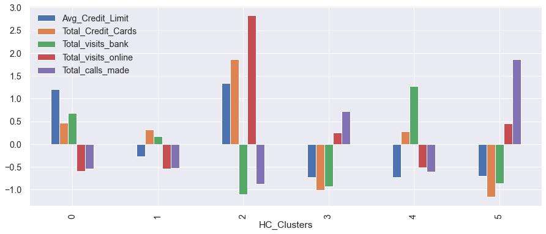

```python
#Plotting bar plot of the clusters by variables
subset_scaled_df_h.groupby('HC_Clusters').mean().plot.bar(figsize=(15,6))
```

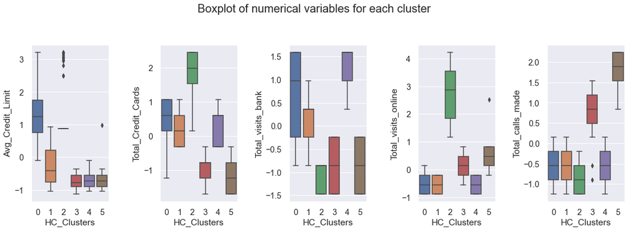

```python
#Blooting bo plots for each variable
fig, axes = plt.subplots(1, 5,  figsize=(16, 6))
fig.suptitle('Boxplot of numerical variables for each cluster', fontsize=20)
counter = 0
for ii in range(5):
    sns.boxplot(ax=axes[ii],y=subset_scaled_df_h[all_col3[counter]],x=subset_scaled_df_h['HC_Clusters'])
    counter = counter+1

fig.tight_layout(pad=2.0)
```

### Models Comparison

**K-Means bar plot by variables**

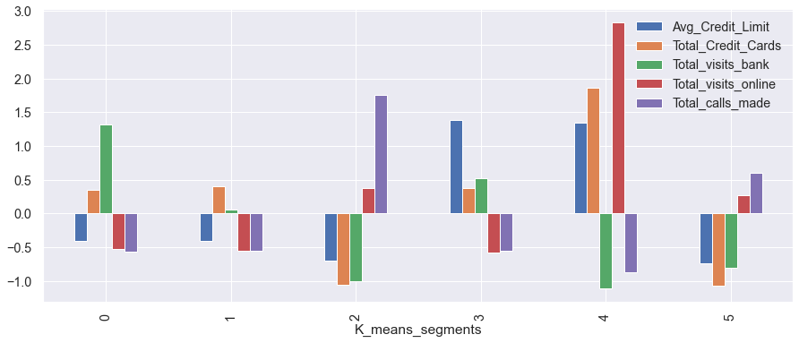

```python
#Plotting bar plot of the clusters by variables
subset_scaled_df_k.groupby('K_means_segments').mean().plot.bar(figsize=(15,6))
```

**Hierarchical Clustering bar plot by variables**

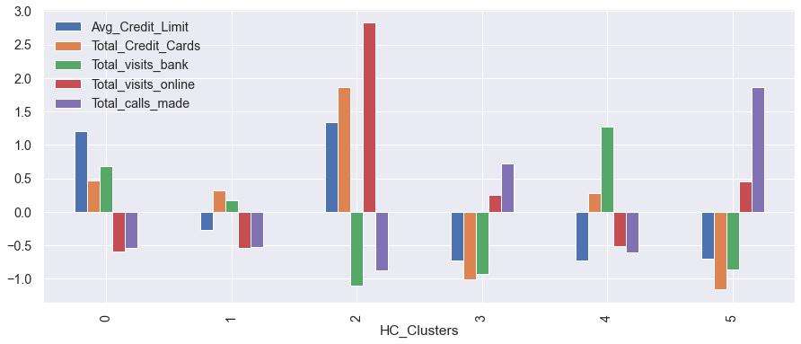

```python
#Plotting bar plot of the clusters by variables
subset_scaled_df_h.groupby('HC_Clusters').mean().plot.bar(figsize=(15,6))
```

**Observations**

- By comparing both models technic using the same number of cluster "6" although can be observed that the Labels of the clusters are mixed up it is very evident that both results were very close each other wiht very small differences for example by looking both plots, cluster number 1, they are not the same but are very close. Another example would be cluster 5 from K_means plot to 3 from HC plot, they are also not the same but there is a very close approximation.
- Insights and business recommendations will be the same drawn from K-means part.

```python
#Export notebook to HTML type.
import os
os.system('jupyter nbconvert --to html Project_All_Life_Bank_Customer_Segmentation.ipynb')
```

```
0
```